# Yelp Open Dataset Sentiment Analysis

It is recommended to view this notebook in html.

A subset of 35,000 restaurant reviews was taken from the [Yelp Open Dataset](https://www.yelp.com/dataset) to perform sentiment analysis on a subset of reviews making use of NLP, word2vec, logistic regression and gradient boosted forests.

The [Natural Language Toolkit (NLTK)](https://www.nltk.org/) was used to pre-process the data and perform tf-idf vectorization, while the [gensim](https://radimrehurek.com/gensim/) was used for word2vec vectorization and [google news word2vec](https://code.google.com/archive/p/word2vec) was used as a large corpus pre-trained word2vec model.

Overall, the best performing model with the highest F1 score was XGBoost with TF-IDF vectorization.

A summary of the models can be seen in the table below:

[output not shown]

The performance of the word2vec models is generally improved by training on a larger corpus of reviews, however the google-news pretrained corpus had a lower performance than the other models, suggesting that the style of writing and the vocabulary used in restaurant reviews differs from those in news stories.

```python
import pandas as pd
import numpy as np
import holoviews as hv

from holoviews import dim, opts
from bokeh.models import HoverTool
import matplotlib.pyplot as plt

import nltk, string, gensim
from nltk.corpus import stopwords
from yellowbrick.text import TSNEVisualizer
from nltk.corpus import stopwords
from nltk.tokenize import TweetTokenizer, sent_tokenize

from sklearn import metrics
from sklearn.feature_extraction.text import TfidfVectorizer
from gensim.models import Word2Vec
from sklearn.linear_model import LogisticRegression
from sklearn.model_selection import GridSearchCV
from xgboost import XGBClassifier
from sklearn.preprocessing import scale

pd.options.mode.chained_assignment = None
%matplotlib inline
```

35,000 randomly chosen eatery reviews from the dataset will be included in the analysis. This is only a small subset of the 6.7M reviews contained in the database, but will allow for much reduced computation time for the purposes of this project.

Before performing sentiment analysis first we will visualize the distribution of review stars. Unlike the overall rating of a business, user reviews cannot award half stars.

A star rating of 4 or higher will be classified as positive sentiment, and a star rating of 3 or below will be classified as negative sentiment. 66% of reviews awarded a star rating of 4 or 5, thus a naive classifier that classifies all reviews to be positive will thus have an accuracy of 0.66.

```python
reviews = pd.read_csv('35k_reviews.csv', header=None)
reviews.columns = ['business_id', 'business_stars', 'is_open', 'categories',
                 'text', 'useful', 'funny', 'cool', 'review_stars', 'user_id', 'user_elite']

hv.extension('bokeh')

rating_dist = hv.Bars(reviews['review_stars'].value_counts(sort=False))
rating_dist.opts(xlabel='Review Stars', ylabel='Frequency', fill_color='#718dbf')

hover = HoverTool(tooltips=[('Frequency',"@review_stars"),('Review Stars',"@index")], mode='vline')

rating_dist.opts(opts.Bars(tools=[hover]))
```

[output not shown]

In order to prepare the data for classification we must clean the data by de-capitalizing letters and removing punctuation.

To get the best classifier performance we must remove non-informational stop words such as 'a' ,'the', 'with' etc. and also lemmatize words to ["remove inflectional endings only and to return the base or dictionary form of a word"](https://nlp.stanford.edu/IR-book/html/htmledition/stemming-and-lemmatization-1.html). For instance the word 'eating' would have a lemmatized form 'eat', and the word 'better' would have a lemmatized form 'good'.

The NLTK module is used to tokenize the words and extract the part-of-speech (pos) tag via a pre-trained set provided by NLTK. The pos tag represents a word's syntactic function, and is parsed by the lemmatizer for best accuracy. The lemmatizer will only parse certain tags, for all words that are not adjectives, adverbs, nouns and verbs we will bypass the lemmatizer.

```python
def get_wordlist(row):
    key_words_lemma = []
    punc = list(string.punctuation)
    tokens = nltk.word_tokenize(row.lower())
    tagged = nltk.pos_tag(tokens)
    lemma = nltk.stem.wordnet.WordNetLemmatizer()
    for word, tag in tagged:
        wntag = tag[0].lower()
        # Convert 'j' adjective tag to 'a' for pos parsing
        if wntag == 'j':
            wntag = 'a'
        if wntag in ['a', 'r', 'n', 'v']:
            word = lemma.lemmatize(word, wntag)
            key_words_lemma.append(word)
        elif wntag in punc or word in punc:
            pass
        else:
            key_words_lemma.append(word)
    return key_words_lemma


def remove_stop_words(row):
    return [word for word in row if word not in stop_words]

stop_words = set(stopwords.words('english'))

reviews['text_bag'] = reviews['text'].apply(get_wordlist).tolist()
reviews['text_bag'] = reviews['text_bag'].apply(remove_stop_words)
```

An example of a review before and after processing can be seen below. Many non-contextual words and stop words have been removed. Verbs and nouns have been reduced to their base lemmas.

```python
print(reviews['text'][2], '\n')
print(reviews['text_bag'][2])
```

```
I cannot believe how things have changed in 3 years. I picked up duck congee sometime in the winter when my hubby was sick.  I was very disappointed because the ginger fish sauce tasted like it had gone bad (it should never be bitter).  Today, my hubby wanted to eat there since he was craving the du…

['believe', 'thing', 'change', '3', 'year', 'pick', 'duck', 'congee', 'sometime', 'winter', 'hubby', 'sick', 'disappointed', 'ginger', 'fish', 'sauce', 'taste', 'like', 'go', 'bad', 'never', 'bitter', 'today', 'hubby', 'want', 'eat', 'since', 'crave', 'duck', 'congee', 'place', "n't", 'serve', 'duck…
```

In order to train a clasifier model we must transfer the collection of words into an input vector. We will consider two vectorization methods.

The second method is word2vec, which represents each word as a high dimensional vectors and weights are assigned based on the similarity between the words. We will make use of the skip-gram neural network model where the vector weights are obtained by the model trying to predict words surrounding a given target word.

```python
# Split data into 80:20 train:test, the reviews are already shuffled

train_split = int(0.8 * len(reviews))

train = reviews[:train_split]
test = reviews[train_split:]

train['sentiment'] = 1
train.loc[train['review_stars']<3.5, 'sentiment'] = 0

test['sentiment'] = 1
test.loc[test['review_stars']<3.5, 'sentiment'] = 0
```

For the tf-idf vectorizer we will include unigrams, bigrams and trigrams, since this was found to give the best classification accuracy. Sublinear_tf is where the term frequency is defined as 1 + log(tf), else 0; this is used because a term that appears 10 times rather than 1 time is unlikely to be actually 10 times more important.

To prevent overfitting, a min_df of 5 is used, meaning terms that appear in less than five reviews are discarded. Likewise, a max_df of 0.8 is used to discard terms that appear in more than 80% of reviews.

```python
vectorizer = TfidfVectorizer(min_df=5, max_df = 0.8, sublinear_tf=True, use_idf =True, ngram_range=(1,3))

train_corpus_tf_idf = vectorizer.fit_transform(train['text_bag'].apply(lambda x: " ".join(x)))
test_corpus_tf_idf = vectorizer.transform(test['text_bag'].apply(lambda x: " ".join(x)))
```

There are several models which can be used for classification. In this project we will utilize logistic regression and gradient boosted forests.

Grid seach CV was used to optimize hyperparameters, although for the sake of run-time the optimized parameters are already given.

With logistic regression incorporating tf-idf vectorization, a test accuracy of 0.88 was achieved, outperforming the baseline of 0.66.

```python
X = train_corpus_tf_idf
Y = train['sentiment']

lr = LogisticRegression()
params = {'C':[10.5],
          'class_weight':['balanced'],
          'solver': ['liblinear']}

grid = GridSearchCV(lr, params, cv=10, scoring='accuracy')
grid.fit(X, Y)
best_params = grid.best_params_
best_score = grid.best_score_

print("LR Cross Val Score", best_score)

x_test_tfidf = test_corpus_tf_idf
y_test = test['sentiment']
pred_lr_tfidf = grid.predict(x_test_tfidf)
y_pred_proba_lr_tfidf = grid.predict_proba(x_test_tfidf)[::,1]

print("LR Test Accuracy", metrics.accuracy_score(y_test, pred_lr_tfidf))
```

```
LR Cross Val Score 0.8886785714285714
LR Test Accuracy 0.8834285714285715
```

With XGBoost we also obtain a test accuracy of 0.88.

```python
xgb = XGBClassifier()
params = {'max_depth':[6],
 'min_child_weight':[3],
 'gamma': [0],
 'subsample': [0.8],
 'colsample_bytree': [0.8],
 'scale_pos_weight': [1],
 'random_state': [0],
 'learning_rate': [0.1],
 'n_estimators':[1200]}

grid = GridSearchCV(xgb, params, cv=10, scoring='accuracy')
grid.fit(X, Y)
best_params = grid.best_params_
best_score = grid.best_score_

print('XGB Cross Val Score', best_score)

x_test_tfidf = test_corpus_tf_idf
y_test = test['sentiment']
pred_xgb_tfidf = grid.predict(x_test_tfidf)
y_pred_proba_xgb_tfidf = grid.predict_proba(x_test_tfidf)[::,1]

print("XGB Test Accuracy", metrics.accuracy_score(y_test, pred_xgb_tfidf))
```

```
XGB Cross Val Score 0.8808214285714285
XGB Test Accuracy 0.8824285714285715
```

In addition to the accuracy, we can also analyze the data using ROC curves, and confusion matricies.

While the accuracy depends on the distribution of classifications on our single test set, the ROC curve allows use to see the performance of our model across a wide range of class distributions. The AUC gives the probability that the model classifies correctly across all class distributions.

From the AUC metric we see that linear regression with auc = 0.95, slightly outperforms XGBoost auc = 0.94.

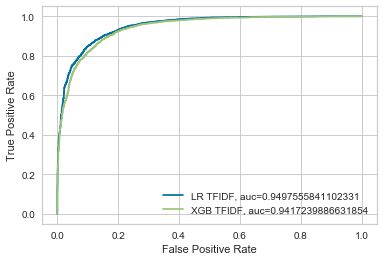

```
TF-IDF Logisitc Regression
               Actual Negative  Actual Positive
Pred Negative             1975              395
Pred Positive              421             4209

Sensitivity 0.9142050390964379
Specificity 0.8242904841402338
Precision 0.9090712742980561
F1 0.9116309291747888

TF-IDF XGBoost
               Actual Negative  Actual Positive
Pred Negative             1876              494
Pred Positive              329             4301

Sensitivity 0.8969760166840459
Specificity 0.8507936507936508
Precision 0.9289416846652268
F1 0.9126790450928381
```

```python
fpr_lr_tfidf, tpr_lr_tfidf, _ = metrics.roc_curve(y_test,y_pred_proba_lr_tfidf)
auc = metrics.roc_auc_score(y_test, y_pred_proba_lr_tfidf)
plt.plot(fpr_lr_tfidf,tpr_lr_tfidf,label="LR TFIDF, auc="+str(auc))

fpr_xgb_tfidf, tpr_xgb_tfidf, _ = metrics.roc_curve(y_test,  y_pred_proba_xgb_tfidf)
auc = metrics.roc_auc_score(y_test, y_pred_proba_xgb_tfidf)
plt.plot(fpr_xgb_tfidf,tpr_xgb_tfidf,label="XGB TFIDF, auc="+str(auc))

plt.legend(loc=4)
plt.xlabel('False Positive Rate')
plt.ylabel('True Positive Rate')
plt.show()

c_mat_lr_tfidf = pd.DataFrame(metrics.confusion_matrix(y_test, pred_lr_tfidf),
                    columns=['Actual Negative', 'Actual Positive'],
                    index = ['Pred Negative', 'Pred Positive'])

tp_lr_tfidf = c_mat_lr_tfidf.iloc[1, 1]
fp_lr_tfidf = c_mat_lr_tfidf.iloc[1, 0]
tn_lr_tfidf = c_mat_lr_tfidf.iloc[0, 0]
fn_lr_tfidf = c_mat_lr_tfidf.iloc[0, 1]

print('TF-IDF Logisitc Regression')
print(c_mat_lr_tfidf, '\n')
print('Sensitivity', tp_lr_tfidf/(tp_lr_tfidf+fn_lr_tfidf))
print('Specificity', tn_lr_tfidf/(tn_lr_tfidf+fp_lr_tfidf))
print('Precision', tp_lr_tfidf/(tp_lr_tfidf+fp_lr_tfidf))
print('F1', (2*tp_lr_tfidf)/((2*tp_lr_tfidf)+fp_lr_tfidf+fn_lr_tfidf), '\n')

c_mat_xgb_tfidf = pd.DataFrame(metrics.confusion_matrix(y_test, pred_xgb_tfidf),
                    columns=['Actual Negative', 'Actual Positive'],
                    index = ['Pred Negative', 'Pred Positive'])

tp_xgb_tfidf = c_mat_xgb_tfidf.iloc[1, 1]
fp_xgb_tfidf = c_mat_xgb_tfidf.iloc[1, 0]
tn_xgb_tfidf = c_mat_xgb_tfidf.iloc[0, 0]
fn_xgb_tfidf = c_mat_xgb_tfidf.iloc[0, 1]

print('TF-IDF XGBoost')
print(c_mat_xgb_tfidf, '\n')
print('Sensitivity', tp_xgb_tfidf/(tp_xgb_tfidf+fn_xgb_tfidf))
print('Specificity', tn_xgb_tfidf/(tn_xgb_tfidf+fp_xgb_tfidf))
print('Precision', tp_xgb_tfidf/(tp_xgb_tfidf+fp_xgb_tfidf))
print('F1', (2*tp_xgb_tfidf)/((2*tp_xgb_tfidf)+fp_xgb_tfidf+fn_xgb_tfidf), '\n')
```

We will now try training our model using word2vec vectorization. First, we perform the same stop word removal and lemmatization, except instead of outputting a list of words for the entire review, we output a list of lists with and individual list for each sentence in the given review.

```python
def get_wordlist(row):
    punc = list(string.punctuation)
    key_words_lemma = []
    tokenizer_words = TweetTokenizer()
    token_sentences = [tokenizer_words.tokenize(t) for t in nltk.sent_tokenize(row.lower())]
    for idx, sentence in enumerate(token_sentences):
        token_sentences[idx] = nltk.pos_tag(sentence)
    lemma = nltk.stem.wordnet.WordNetLemmatizer()
    for i1, sentence in enumerate(token_sentences):
        sentence_lemma = []
        for i2, (word, tag) in enumerate(sentence):
            wntag = tag[0].lower()
            if wntag == 'j':
                wntag = 'a'
            if wntag in ['a', 'r', 'n', 'v']:
                word = lemma.lemmatize(word, wntag)
                sentence_lemma.append(word)
            elif wntag in punc or word in punc:
                pass
            else:
                sentence_lemma.append(word)
        key_words_lemma.append(sentence_lemma)
    return key_words_lemma


def remove_stop_words(row):
    for idx, sentence in enumerate(row):
        row[idx] = [word for word in row[idx] if word not in stop_words]
    return row

stop_words = set(stopwords.words('english'))

reviews['w2v_text_bag'] = reviews['text'].apply(get_wordlist).tolist()
reviews['w2v_text_bag'] = reviews['w2v_text_bag'].apply(remove_stop_words)
```

```python
# Re-initialize train and test data
train_split = int(0.8 * len(reviews))

train = reviews[:train_split]
test = reviews[train_split:]

train['sentiment'] = 1
train.loc[train['review_stars']<3.5, 'sentiment'] = 0

test['sentiment'] = 1
test.loc[test['review_stars']<3.5, 'sentiment'] = 0
```

We initialize the word2vec model with 300 dimensions and the skip-gram model. We must also convert all the individual word vectors for a given review into a single vector for input into our classification models. One way to do this is to average all the word vectors for a given review and use the average vector as the model input.

```python
# Turn off info messages in the notebook
import logging
logger = logging.getLogger()
logger.setLevel(logging.CRITICAL)

# Initialize word2vec model with 300 dimensions and skip-gram model
ndim = 300
w2v_input = [item for sublist in train['w2v_text_bag'].tolist() for item in sublist]
model = Word2Vec(size=ndim, window=8, min_count=2, sg=1, workers=10, seed=1)
model.build_vocab(w2v_input)

model.train(w2v_input, total_examples=len(w2v_input), epochs=model.epochs)

def review_average_vector(text, ndim):
    vector = np.zeros(ndim).reshape((1, ndim))
    i = 0
    for sentence in text:
        for word in sentence:
            try:
                vector += model[word].reshape((1, ndim))
                i += 1
            except KeyError:
                pass
    if i != 0:
        vector /= i
    return vector

train_vecs = np.concatenate([review_average_vector(text, ndim) for text in train['w2v_text_bag']])
train_vecs = scale(train_vecs)

test_vecs = np.concatenate([review_average_vector(text, ndim) for text in test['w2v_text_bag']])
test_vecs = scale(test_vecs)
```

Next we input our vectors into a a logistc regression classifier. We see that the of 0.86 is slightly lower than that of tf-idf. Word2vec is known to require a large corpus of text to train from, so it is possible that with by including more than 35,000 reviews that word2vec would outperform tf-idf.

When comparing the sensitivity word2vec (0.92) outperforms both logistic regression tf-idf (0.91) and xgb tf-idf (0.90), so if having a high true positive rate was most important, we may consider the word2vec model to be the best.

```
Cross Val Score 0.8633571428571428
Test Accuracy 0.8608571428571429
```

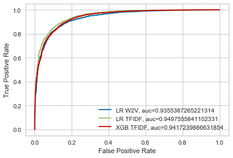

```
Word2vec Logisitc Regression
               Actual Negative  Actual Positive
Pred Negative             2059              311
Pred Positive              663             3967

Sensitivity 0.9273024777933614
Specificity 0.7564290962527553
Precision 0.8568034557235421

F1 0.8906600808262236
```

```python
X = train_vecs
Y = train['sentiment']

lr = LogisticRegression()
params = {'C':[7.3],
          'class_weight':['balanced'],
          'solver': ['liblinear']}

grid = GridSearchCV(lr, params, cv=10, scoring='accuracy')
grid.fit(X, Y)
best_params = grid.best_params_
best_score = grid.best_score_

print("Cross Val Score", best_score)

x_test_lr_w2v = test_vecs
y_test = test['sentiment']
pred_lr_w2v = grid.predict(x_test_lr_w2v)

print("Test Accuracy", metrics.accuracy_score(y_test, pred_lr_w2v))

y_pred_proba_lr_w2v = grid.predict_proba(x_test_lr_w2v)[::,1]

fpr_lr_w2v, tpr_lr_w2v, _ = metrics.roc_curve(y_test, y_pred_proba_lr_w2v)
auc = metrics.roc_auc_score(y_test, y_pred_proba_lr_w2v)
plt.plot(fpr_lr_w2v,tpr_lr_w2v,label="LR W2V, auc="+str(auc))

fpr_lr_tfidf, tpr_lr_tfidf, _ = metrics.roc_curve(y_test,y_pred_proba_lr_tfidf)
auc = metrics.roc_auc_score(y_test, y_pred_proba_lr_tfidf)
plt.plot(fpr_lr_tfidf,tpr_lr_tfidf,label="LR TFIDF, auc="+str(auc))

fpr_xgb_tfidf, tpr_xgb_tfidf, _ = metrics.roc_curve(y_test,  y_pred_proba_xgb_tfidf)
auc = metrics.roc_auc_score(y_test, y_pred_proba_xgb_tfidf)
plt.plot(fpr_xgb_tfidf,tpr_xgb_tfidf,label="XGB TFIDF, auc="+str(auc))

plt.legend(loc=4)
plt.xlabel('False Positive Rate')
plt.ylabel('True Positive Rate')
plt.show()

c_mat_lr_w2v = pd.DataFrame(metrics.confusion_matrix(y_test, pred_lr_w2v),
                    columns=['Actual Negative', 'Actual Positive'],
                    index = ['Pred Negative', 'Pred Positive'])

tp_lr_w2v = c_mat_lr_w2v.iloc[1, 1]
fp_lr_w2v = c_mat_lr_w2v.iloc[1, 0]
tn_lr_w2v = c_mat_lr_w2v.iloc[0, 0]
fn_lr_w2v = c_mat_lr_w2v.iloc[0, 1]

print('Word2vec Logisitc Regression')
print(c_mat_lr_w2v, '\n')
print('Sensitivity', tp_lr_w2v/(tp_lr_w2v+fn_lr_w2v))
print('Specificity', tn_lr_w2v/(tn_lr_w2v+fp_lr_w2v))
print('Precision', tp_lr_w2v/(tp_lr_w2v+fp_lr_w2v), '\n')
print('F1', (2*tp_lr_w2v)/((2*tp_lr_w2v)+fp_lr_w2v+fn_lr_w2v), '\n')
```

```python
X = train_vecs
Y = train['sentiment']

params = {'max_depth':[7],
 'min_child_weight':[4],
 'gamma': [0],
 'subsample': [0.8],
 'colsample_bytree': [0.8],
 'scale_pos_weight': [0.8],
 'random_state': [0],
 'learning_rate': [0.1],
 'n_estimators':[1200]}

grid = GridSearchCV(xgb, params, cv=10, scoring='accuracy')
grid.fit(X, Y)
best_params = grid.best_params_
best_score = grid.best_score_

print("Cross Val Score", best_score)

x_test_xgb_w2v = test_vecs
y_test = test['sentiment']
pred_xgb_w2v = grid.predict(x_test_xgb_w2v)

print("Test Accuracy", metrics.accuracy_score(y_test, pred_xgb_w2v))

y_pred_proba_xgb_w2v = grid.predict_proba(x_test_xgb_w2v)[::,1]

c_mat_xgb_w2v = pd.DataFrame(metrics.confusion_matrix(y_test, pred_xgb_w2v),
                    columns=['Actual Negative', 'Actual Positive'],
                    index = ['Pred Negative', 'Pred Positive'])

tp_xgb_w2v = c_mat_xgb_w2v.iloc[1, 1]
fp_xgb_w2v = c_mat_xgb_w2v.iloc[1, 0]
tn_xgb_w2v = c_mat_xgb_w2v.iloc[0, 0]
fn_xgb_w2v = c_mat_xgb_w2v.iloc[0, 1]

print('Word2vec XGBoost')
print(c_mat_xgb_w2v, '\n')
print('Sensitivity', tp_xgb_w2v/(tp_xgb_w2v+fn_xgb_w2v))
print('Specificity', tn_xgb_w2v/(tn_xgb_w2v+fp_xgb_w2v))
print('Precision', tp_xgb_w2v/(tp_xgb_w2v+fp_xgb_w2v), '\n')
print('F1', (2*tp_xgb_w2v)/((2*tp_xgb_w2v)+fp_xgb_w2v+fn_xgb_w2v), '\n')
```

```
Cross Val Score 0.8697857142857143
Test Accuracy 0.8668571428571429
Word2vec XGBoost
               Actual Negative  Actual Positive
Pred Negative             1850              520
Pred Positive              412             4218

Sensitivity 0.8902490502321655
Specificity 0.8178603006189213
Precision 0.9110151187904968

F1 0.9005123825789924
```

Finally, the google-news pretrained word2vec model is used to predict reviews. As the model is several GB in size, the results are summarized in the below table:

[output not shown]

The google news word2vec implementation trained on several billion words performs worse than word2vec trained on the limited set of reviews in the training set. Due to memory limitations, only the first 4,000,000 vectors were included which may have degraded performance. Another possibility is that the style of writing used on reviews differs from that of news articles, so that the pre-trained vectors are not as effective at associating sentiment within restaurant reviews than a word2vec model trained purely on reviews.